# Good Plot Bad Plot

Diana Gao

2024-10-29

# Setup

#### Loading Libraries

```r
library(here)
library(tidyverse)
library(tidytuesdayR)
library(stringr)
library(ggridges)      ## ridgeline plots
library(ggpubr)
```

#### Loading in Data

I chose the tidytuesday cheese dataset :D

```r
tuesdata <- tidytuesdayR::tt_load(2024, week = 23)
cheeses <- tuesdata$cheeses
head(cheeses) # peek at the data
```

```
## # A tibble: 6 × 19
##   cheese     url   milk  country region family type  fat_content calcium_content
##   <chr>      <chr> <chr> <chr>   <chr>  <chr>  <chr> <chr>       <chr>
## 1 Aarewasser http… cow   Switze… <NA>   <NA>   semi… <NA>        <NA>
## 2 Abbaye de… http… sheep France  Pays … <NA>   semi… <NA>        <NA>
## 3 Abbaye de… http… cow   France  <NA>   <NA>   semi… 40-46%      <NA>
## 4 Abbaye de… http… cow   France  Burgu… <NA>   semi… <NA>        <NA>
## 5 Abbaye de… http… cow   France  Savoie <NA>   soft… <NA>        <NA>
## 6 Abbaye de… http… cow   France  provi… <NA>   semi… <NA>        <NA>
## # ℹ 10 more variables: texture <chr>, rind <chr>, color <chr>, flavor <chr>,
## #   aroma <chr>, vegetarian <lgl>, vegan <lgl>, synonyms <chr>,
## #   alt_spellings <chr>, producers <chr>
```

#### Clean the Data

I want to plot the fat content of each flavor note to see if there are any possible relationships. Several things must be done first to the data:  
1. Select out the appropriate columns  
2. Remove NAs  
3. To simplify, select only columns with a single percent fat content (mixed formatting, some have a range of percents)  
4. Separate out columns like flavor that have multiple data points in one cell eg. (fruity, savory)  
For fun, I also made a “hard” and “soft” category to see if there is any difference in fat content to flavor relationship. It seems like not really.

```r
cheeseclean <- cheeses %>%
  select(cheese, type, flavor, color, fat_content) %>% # select out these cols
  mutate(Hard =  str_detect(cheeses$type, "hard")|str_detect(cheeses$type, "firm")) %>% # make a col if it is hard or firm then true
  mutate(Soft = str_detect(cheeses$type, "soft")) %>% # make a col if it is soft then true
  drop_na(cheese, type, flavor, color, fat_content) %>% # drop NAs in these cols
  separate(type, c("type1", "type2", "type3"), sep = ",") %>% # separate type column by commas
  select(cheese, type1, flavor, color, fat_content, Hard, Soft) %>% # out type2 and type3 cols bc they are redundant, only type1 col kept
  filter(str_detect(fat_content, "^[0-9]{2}[%]") | str_detect(fat_content, "^[0-9]{2}[\\.][0-9]{1,3}[%]")) %>% # only select the rows with ONE % in the fat content
  separate_longer_delim(flavor, delim = ", ") %>% # separate all the notes into different rows with all other info repeated
  mutate(flavor = str_trim(flavor))
```

At the end I notice the fat content is in character format, so I change the percents to decimals and make the data into numeric format

```r
cheeseclean$fat_content <- as.numeric(gsub("%", "", cheeseclean$fat_content)) / 100 # fat content was character, turn into numeric decimal
```

# Plotting

Now we can plot the data, starting wiiiiithhhh:

#### Bad plot

I first tried viewing the data in a jitter plot and realized it was illegible. So I stuck with this for the bad plot :)

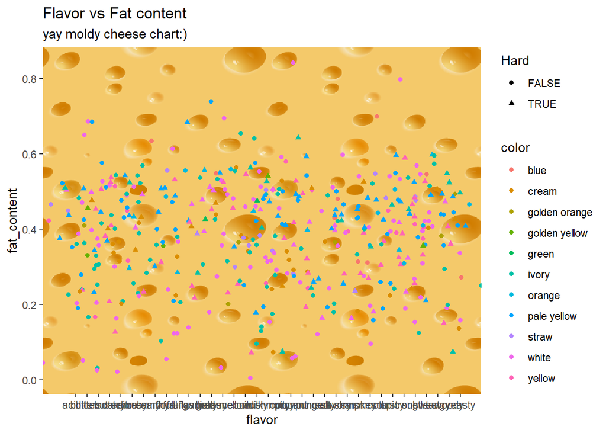

```r
img.file <- here("goodplotbadplot", "data", "cheese.png")
img <- png::readPNG(img.file)
ggplot(cheeseclean, aes(x=flavor, y = fat_content, shape = Hard, color = color)) +
  background_image(img) +
  geom_jitter(width = 3, height = .1) +
  labs(title = "Flavor vs Fat content",
       subtitle = "yay moldy cheese chart:)") +
  theme(panel.background = element_blank(), panel.grid.major = element_blank(), panel.grid.minor = element_blank())
```

Why this is bad:  
1. Too many flavors on the x! Can’t read any of them  
2. This means that the data that corresponds to each flavor is completely indistinguishable  
2. Color is determined by cheese color but the color of the point doesn’t match the color of the cheese at all  
3. Y axis should be in percents  
4. It’s moldy :(

#### Good plot

Now let’s try that again

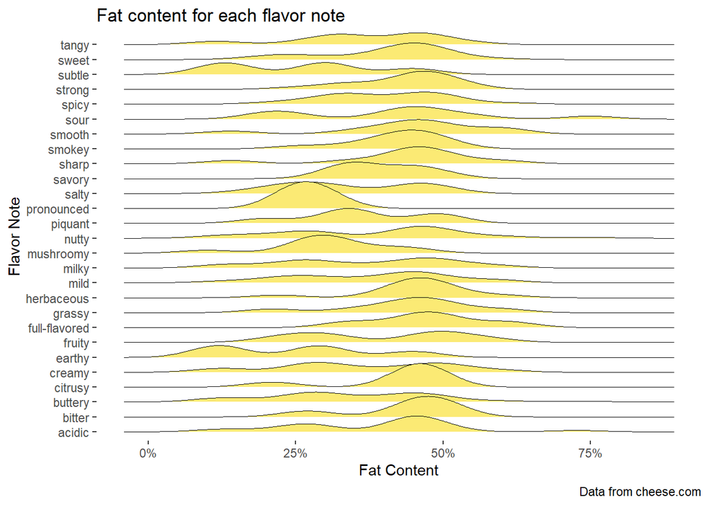

```r
cheeseclean %>%
  filter(flavor != "yeasty" & flavor != "woody" & flavor != "pungent" & flavor != "mellow" & flavor != "garlicky" & flavor != "caramel" & flavor != "floral" & flavor != "butterscotch") %>% # remove notes that aren't showing up (not enough data)
  ggplot(aes(fat_content, flavor)) +
  geom_density_ridges(linewidth = 0, fill = "#FBEA74") + # ridge plot showing the fat content distribution for each flavor note
  scale_x_continuous(labels = scales::percent) + # change x axis to percent format
  labs(title = "Fat content for each flavor note",
       x = "Fat Content",
       y = "Flavor Note",
       caption = "Data from cheese.com") +
  theme_bw() +
  theme(panel.border = element_blank(),
        panel.grid.major = element_blank(),
        panel.grid.minor = element_blank())
```

Wow how great!!! Looks like most certain notes (like “pronounced”) are predominantly present in lower fat cheeses.

This is a good plot because:  
1. It’s legible lol  
2. Fat content is actually formatted in percents  
3. Has clear title and caption showing what is trying to be depicted and caption of where data is from